# Key 06 t-tests

**Instructions for writing KEY and HW**

1. update libraries and data
   1. In setup block (hidden) and in **SETUP** sections below
2. Add graded comment to code block and as a 2nd-level header above problem
3. Once Key is complete
   1. Delete this instruction callout
   2. Render
4. After key is complete
   1. “save as” appropriate HW in `assignment/` folder
   2. Change `echo:` and `eval:` to `false` in YAML
   3. Delete GRADED headers
   4. Render assignment
      1. Ensure that code and output are not visible

# Learning Objectives

Following this assignment students should be able to:

- Define the null and alternative hypotheses for three kinds of t-tests
- Interpret results in writing, including relevant statistical information
- Perform a one-sample t-test manually
- Perform a one-sample t-test using the `lm()` function
- Perform a two-sample t-test using the `lm()` function
- Perform a paired t-test using the `lm()` function

# Setup

## Libraries

```r
library(tidyverse)
```

## Data

- Download the “body_temp_hr.csv” from D2L
- Place it in your `data/` folder
- Load the following data into your script
- Be sure to run the two lines of code to modify the `finch` data to `scandens` :

```r
# data for problem 1 and 3
bt_samp <- read_csv("data/body_temp_hr.csv")

# data for problem 2
finch <- read_csv("data/galapago-finches.csv")
# modify data for problem 2
scandens <- finch |>
  filter(species == "scandens") |>
  as_tibble()
scandens$year <- as.character(scandens$year)

# data for problem 4
darwin_maize <- read_csv("data/darwin_maize.csv")
```

# Problems

### Data: `bt_samp`

## Problem 1: One-sample t-test

We will be formally testing whether the true population mean of human body temperatures is equal to 98.6 degrees Fahrenheit.

1.1 Add a comment to your homework script stating the null and alternative hypotheses. Make sure to put each hypothesis on its own line. Make sure that your alternative hypothesis is 2-tailed.

```r
# Null: Mu = 98.6 OR Mu - 98.6 = 0
# Alternative: Mu != 98.6 OR Mu - 98.6 != 0
```

1.2 Make a box plot of body temperature. Be sure to include a dashed line at our $\mu_0$ value

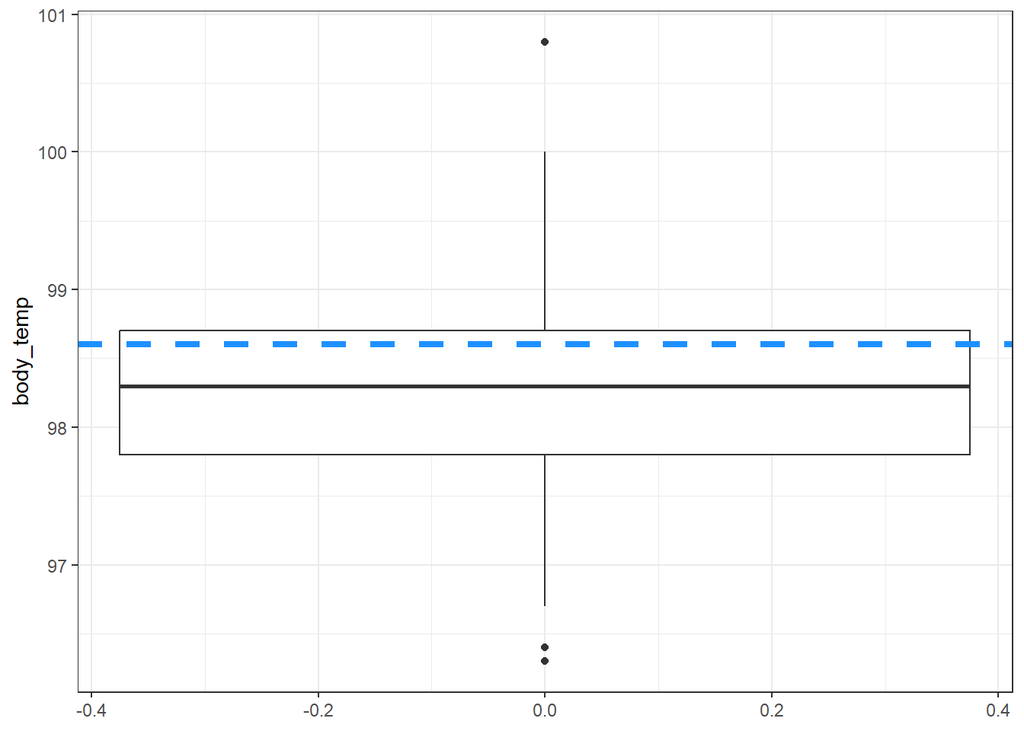

```r
ggplot(data = bt_samp,
       aes(y = body_temp)) +
  geom_boxplot() +
  geom_hline(yintercept = 98.6,
             linewidth = 1.5,
             linetype = "dashed",
             color = "dodgerblue") +
  theme_bw()
```

1.3 Add a comment to your script making a prediction: Do you think the average body temperature is going to be different from 98.6 degrees? Why or why not?

```r
# Not graded, just looking for interpretation and that you are thinking about the data and hypotheses.
```

1.4 Extract the `body_temp` column/variable from `bt_samp` and store it as a vector called `b`.

```r
b <- bt_samp$body_temp
b
```

```
  [1]  96.3  96.7  96.9  97.0  97.1  97.1  97.1  97.2  97.3  97.4  97.4  97.4
 [13]  97.4  97.5  97.5  97.6  97.6  97.6  97.7  97.8  97.8  97.8  97.8  97.9
 [25]  97.9  98.0  98.0  98.0  98.0  98.0  98.0  98.1  98.1  98.2  98.2  98.2
 [37]  98.2  98.3  98.3  98.4  98.4  98.4  98.4  98.5  98.5  98.6  98.6  98.6
 [49]  98.6  98.6  98.6  98.7  98.7  98.8  98.8  98.8  98.9  99.0  99.0  99.0
 [61]  99.1  99.2  99.3  99.4  99.5  96.4  96.7  96.8  97.2  97.2  97.4  97.6
 [73]  97.7  97.7  97.8  97.8  97.8  97.9  97.9  97.9  98.0  98.0  98.0  98.0
 [85]  98.0  98.1  98.2  98.2  98.2  98.2  98.2  98.2  98.3  98.3  98.3  98.4
 [97]  98.4  98.4  98.4  98.4  98.5  98.6  98.6  98.6  98.6  98.7  98.7  98.7
[109]  98.7  98.7  98.7  98.8  98.8  98.8  98.8  98.8  98.8  98.8  98.9  99.0
[121]  99.0  99.1  99.1  99.2  99.2  99.3  99.4  99.9 100.0 100.8
```

1.5 Create new variables for the mean, SD and SEM of the vector `b`. Be sure that the values print out when you source your script so that I can check your work.

```r
(mean_b <- mean(b))
```

```
[1] 98.24923
```

```r
(b_sd <- sd(b))
```

```
[1] 0.7331832
```

```r
(sem_b <- b_sd / sqrt(length(b)))
```

```
[1] 0.06430442
```

1.6 Calculate a t-statistic and print it out to your console.

- **HINT** Name it something different from the class example so that you don’t get confused which variable is which.

```r
(t_statistic <- (mean_b - 98.6) / sem_b)
```

```
[1] -5.454823
```